# CSC-496/696: Natural Language Processing and Text as Data

Lecture 5: Text Preprocessing

Patrick Wu

Tuesday, September 10, 2024

## Topics Today

- Regular expressions
- Bag of words
- $n$-grams

## Course Logistics Notes

- Last lecture was posted on Canvas
  - Let me know if you cannot access it
- Assignment 1 due this Friday
- Office hours on Thursday from 3-5pm
- Any questions?

## Regular Expressions

- Algebraic notation for characterizing a set of strings
- Particularly useful when we want to search in text and we have a specific pattern to search for
- `re` is the standard library to work with *r*egular *e*xpressions
- Most ordinary characters match to themselves: “cat” will match to “cat”.

## Regular Expressions: Example

```python
import re
text = "The cat sat on the mat."
pattern = "cat"
matches = re.findall(pattern, text)
print(matches)
```

```
['cat']
```

```python
text2 = "The cat sat on the mat with the other cat."
matches2 = re.findall(pattern, text2)
print(matches2)
```

```
['cat', 'cat']
```

But note that the regular expression is case-sensitive.

```python
text3 = "The cat sat on the mat with the other cat named Cat."
matches3 = re.findall(pattern, text3)
print(matches3)
```

```
['cat', 'cat']
```

## Searching for Text

You can use `re.search()` to scan through a string and look for the first location where it produces a match. It will tell you the *span* (the indices of the string where the character is).

```python
text_cat = "The cat sat on the mat with the other cat named Cat."
pattern = "cat"
match_the_cat = re.search(pattern, text_cat)
print(match_the_cat)
print(match_the_cat.span())
```

```
<re.Match object; span=(4, 7), match='cat'>
(4, 7)
```

## Word-agnostic

REs are word-agnostic. In other words, they treat the entire string as simply a *sequence of characters*, including spaces. So if our RE was `\cat\`, “cats” would return true as well.

```python
text_cat = "The cat sat on the mat with the other cat named Cat. They are both cats."
match = re.findall("cat", text_cat)
print(match)
```

```
['cat', 'cat', 'cat']
```

## Disjunction

What if we want to find both “Cat” and “cat”? We can use a *disjunction*, denoted by square brackets `[` and `]`. This means match *any* characters in the bracket.

```python
text_cat = "The cat sat on the mat with the other cat named Cat. They are both cats."
match = re.findall("[cC]at", text_cat)
print(match)
```

```
['cat', 'cat', 'Cat', 'cat']
```

```python
text_schedule = "I can meet there from 9am to 5pm."
match = re.findall("[1234567890]", text_schedule)
print(match)
```

```
['9', '5']
```

## Sequences Associated with a Set of Characters

- It would be really inconvenient to type out `\[ABCDEFGHIJKLMNOPQRSTUVWXYZ]\` if we wanted to find any capital letters
- There are well-defined sequences associated with a set of characters, using the dash character `-` to specify any one character in that range.

```python
text_schedule = "I can meet there from 9am to 5pm."
match = re.findall("[A-Z]", text_schedule)
print(match)
```

```
['I']
```

## Sequences Associated with a Set of Characters

```python
text_schedule = "I can meet there from 9am to 5pm."
match = re.findall("[a-z]", text_schedule)
print(match)
```

```
['c', 'a', 'n', 'm', 'e', 'e', 't', 't', 'h', 'e', 'r', 'e', 'f', 'r', 'o', 'm', 'a', 'm', 't', 'o', 'p', 'm']
```

```python
text_schedule = "I can meet there from 9am to 5pm."
match = re.findall("[0-9]", text_schedule)
print(match)
```

```
['9', '5']
```

## Indicating What a Character *Cannot* Be

- Use the caret, `^`
- Must be the first symbol after the open square brace; otherwise, stands for a caret

```python
text_schedule = "I can meet there from 9am to 5pm."
match = re.findall("[^0-9]", text_schedule)
print(match)
```

```
['I', ' ', 'c', 'a', 'n', ' ', 'm', 'e', 'e', 't', ' ', 't', 'h', 'e', 'r', 'e', ' ', 'f', 'r', 'o', 'm', ' ', 'a', 'm', ' ', 't', 'o', ' ', 'p', 'm', '.']
```

## Indicating What a Character *Cannot* Be

```python
text_schedule = "I can meet there from 9am to 5pm.^^"
match = re.findall("[0-9^]", text_schedule)
print(match)
```

```
['9', '5', '^', '^']
```

## Indicating Either a Character or Nothing

- A question mark, `\?\`, indicates that the match should be the preceding character or nothing
- In other words, a question mark means zero or one instances of the previous character

```python
text_color = "Finding the color in life!"
match = re.findall("colou?r", text_color)
print(match)
```

```
['color']
```

```python
text_color_british = "Finding the colour in life!"
match_british = re.findall("colou?r", text_color_british)
print(match_british)
```

```
['colour']
```

## Kleene *

- An asterisk, *, or Kleene star, indicates “zero or more occurrences of the immediately preceding character or regular expression”
- Note that means if the previous character doesn’t even ever occur, this will return the empty string (because the empty string is zero or more occurrences)

```python
text_color_british = "Finding the colour in life! Haha, it's British."
match_british = re.findall("Ba*", text_color_british)
print(match_british)
```

```
['B']
```

## Kleene +

- A plus sign, +, or Kleene plus, means “one or more occurrences of the immediately preceding character or regular expression”

```python
text_schedule = "I can meet there from 9am to 5pm, but I can't be there from 8am and 9am, and after 5pm."
match = re.findall("[0-9]+", text_schedule)
print(match)
```

```
['9', '5', '8', '9', '5']
```

## The Wildcard Expression: .

- The period, `\.\`, is a wildcard expression that matches any single character except a carriage return

```python
text_cat = "The cat sat on the mat with the other cat named Cat. They are both cats."
match = re.findall("cat.*cat", text_cat)
print(match)
```

```
['cat sat on the mat with the other cat named Cat. They are both cat']
```

## Anchors

- Anchors: special characters that *anchor* regular expressions to particular places in a string
- `^`: start of line
- `$`: end of line
- `\b`: word boundary
- `\B`: non-word boundary

## Anchors

- Anchors allow us to start finding entire words (note that “cats” was returned when we originally used the regular expression `\cat\`)
- Definition of “Word”: defined as any sequence of digits, underscores, or letters

## Anchors: `\b`

```python
text_cat = "The cat sat on the mat with the other cat named Cat. They are both cats."
match = re.findall(r"\bcat\b", text_cat) # why do I need the raw string "r" here?
print(match)
```

```
['cat', 'cat']
```

```python
text_cat = "The $cat sat on the mat with the other cat named Cat. They are both cats."
match = re.findall(r"\bcat\b", text_cat) # dollar sign not a digit, underscore, or letter
print(match)
```

```
['cat', 'cat']
```

## Anchors: `\B`

```python
text_cat = "The cat sat on the mat with the other cat named Cat. They are both cats."
match = re.findall(r"\Bcat\B", text_cat)
print(match)
```

```
[]
```

```python
text_cat = "The cat sat on the mat with the other cat named Decatur. They are both cats."
match = re.findall(r"\Bcat\B", text_cat)
print(match)
```

```
['cat']
```

## Disjunction Operator

- The disjunction operator allows us to to search for “cat” or “dog”
- Indicated by the pipe symbol, `|`
- Often used with the parentheses operators, ( and )
- Used because of precedence: looking for `\puppy|ies\` will only yield “puppy” or “ies”

## Disjunction Operator

- Note that the parentheses will create a *capturing group*

```python
text_pup = "The puppies sat on the mat with the other puppy named Puppers"
match = re.findall("pupp(y|ies)", text_pup)
print(match)
```

```
['ies', 'y']
```

```python
text_pup = "The puppies sat on the mat with the other puppy named Puppers"
match = re.findall("puppies|puppy", text_pup)
print(match)
```

```
['puppies', 'puppy']
```

## Walking Through an Example

- Suppose we wanted to write a regular expression to find cases of the word *cat* used in email addresses
- `cat` is not correct because it would miss “Cat”
- So updated, it would be: `[cC]at`
- We can’t use boundaries because it might be “_cat” or “cat39”
- So let’s keep anything around the word “cat” except letters: `[^a-zA-Z][cC]at[^a-zA-Z]`

## Walking Through an Example

- But what if “cat” is used at the beginning of the email? -`[^a-zA-Z][cC]at[^a-zA-Z]` assumes that there is some character before “cat”
- So updated, it is: `(^|[^a-zA-Z])([cC]at)([^a-zA-Z]|$)`
- We need a parentheses around `[cC]at` because we want the “cat” in emails to be captured

## Walking Through an Example

```python
text_email = "cat_25@gmail.com"
match = re.findall("(^|[^a-zA-Z])([cC]at)([^a-zA-Z]|$)", text_email)
print(match)
```

```
[('', 'cat', '_')]
```

## What if we just want “cat”?

```python
text_email = "cat_25@gmail.com concatenating@gmail.com 77cat@hotmail.com"
match = re.findall("(^|[^a-zA-Z])([cC]at)([^a-zA-Z]|$)", text_email)
print(match)
```

```
[('', 'cat', '_'), ('7', 'cat', '@')]
```

## Regex can get really complicated…ChatGPT can help

[figure not shown]

## Regex can get really complicated…ChatGPT can help

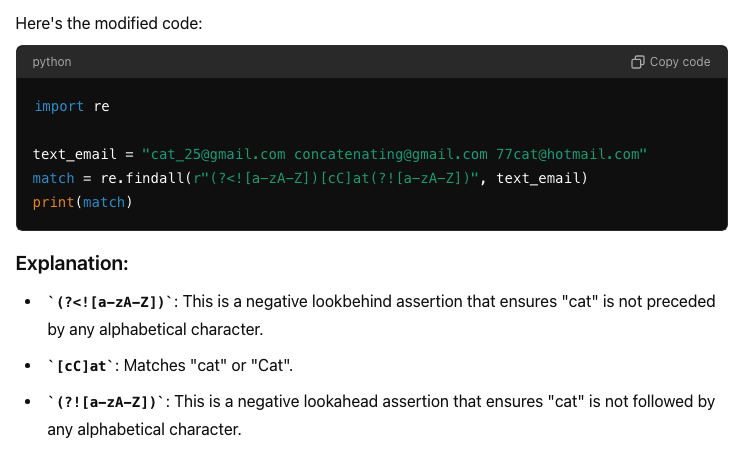

## Regex can get really complicated…ChatGPT can help

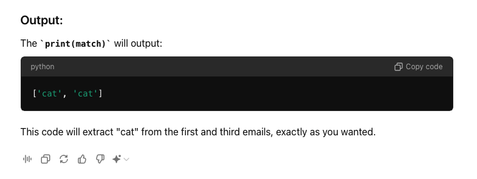

## Regex can get really complicated…ChatGPT can help

```python
text_email = "cat_25@gmail.com concatenating@gmail.com 77cat@hotmail.com"
match = re.findall(r"(?<![a-zA-Z])[cC]at(?![a-zA-Z])", text_email)
print(match)
```

```
['cat', 'cat']
```

## But always make sure you know exactly what your regex is doing!!

- Let’s say I only want to keep tweets that discuss the U.S.
- So any article title that has the country Oman in it needs to be removed
- Let’s say I already preprocessed this text, so it is all lowercased

```python
article_title = "tourism is the fastest growing industry in oman"
match = re.search(r"oman", article_title)
print(match)
```

```
<re.Match object; span=(43, 47), match='oman'>
```

## But always make sure you know exactly what your regex is doing!!

```python
article_title = "anna sutherland bissell was the first woman ceo in the united states"
match = re.search(r"oman", article_title)
print(match)
```

```
<re.Match object; span=(39, 43), match='oman'>
```

The correct regex is:

```python
article_title = "anna sutherland bissell was the first woman ceo in the united states"
match = re.search(r"\boman\b", article_title)
print(match)
```

```
None
```

## Bag of Words Model

- We want a *numerical representation* of each document
- The simplest is called a **bag of words** model
- We represent each document by counting the number of times each word appears the document

## Bag of Words Model

```python
docs = ['what a cute cat!',
        'what a cute dog!',
        'hello world',
        'cat cat cat dog']
```

|  | what | a | cute | cat | dog | hello | world |
| --- | --- | --- | --- | --- | --- | --- | --- |
| Doc 1 | 1 | 1 | 1 | 1 | 0 | 0 | 0 |
| Doc 2 | 1 | 1 | 1 | 0 | 1 | 0 | 0 |
| Doc 3 | 0 | 0 | 0 | 0 | 0 | 1 | 1 |
| Doc 4 | 0 | 0 | 0 | 3 | 1 | 0 | 0 |

## Bag of Words Model

- Each document is represented as a **vector**
- The entire corpus is represented as a document-term **matrix**
- (We’re already seeing the linear algebra!)

## Tokenization

- What we just did was *tokenization*
- Tokenization: segmenting a document into constituent *tokens*
- Tokens: the individual units at which we break up the text
- Tokens do not have to be individual words
- We can even break up the text into individual letters

## Tokenization

- **Discussion**: Why might we want to use more than just individual words per token?
- Certain combinations of words have meanings that differ from their constituent words
- Example: White House
- We can recover some of these meanings by using $n$-grams

## $n$-grams

- $n$-grams: ordered set of $n$ words
- Unigrams: single words
- Bigrams: *ordered* pairs
- Trigrams: *ordered* triples
- …And so on

## $n$-grams

- Bigrams/trigrams can significantly grow the size of our *vocabulary*
- $\mathbf{V} =$ vocabulary
- $|\mathbf{V}|$: size of vocabulary
- The vocabulary is both defined by the corpus (what words appear) and how we tokenize the text

## $n$-grams

```python
docs = ['what a cute cat!',
        'what a cute dog!',
        'hello world',
        'cat cat cat dog']
```

|  | what | a | cute | cat | dog | hello | world | what a | a cute | cute cat | . . . |
| --- | --- | --- | --- | --- | --- | --- | --- | --- | --- | --- | --- |
| Doc 1 | 1 | 1 | 1 | 1 | 0 | 0 | 0 | 1 | 1 | 1 | . . . |
| Doc 2 | 1 | 1 | 1 | 0 | 1 | 0 | 0 | 1 | 1 | 0 | . . . |
| Doc 3 | 0 | 0 | 0 | 0 | 0 | 1 | 1 | 0 | 0 | 0 | . . . |
| Doc 4 | 0 | 0 | 0 | 3 | 1 | 0 | 0 | 0 | 0 | 0 | . . . |

## Generating Bigrams

1. Use all bigrams
2. Preprocess text so specific phrases such as “White House” are connected using an underscore, like “white_house”

   $\to$ Need a list of bigrams (or trigrams)
3. Using statistical tests

   $\to$ If the probability of seeing “white house” relative to “white” and “house” is high enough, we can add it to our list of bigrams

## Reducing Vocabulary Size

- Recall that if we add bigrams, we can also increase the vocabulary size

  $\to$ [“white”, “house”, “white_house”]
- Adding trigrams can even increase the vocabulary size further

## Reducing Vocabulary Size

- Common preprocessing techniques
  - Lowercasing
  - Removing punctuation
  - Removing numbers
  - Removing stopwords
  - Lemmatizing/stemming
  - Filtering by frequency

## Lowercasing

- We lowercase everything
- “We love cats! Cats love us!” $\to$ “we love cats! cats love us!”
- Notice that “cats” and “Cats” were previously separate tokens. After lowercasing, they are the same. $\to$ reduced vocabulary size

## Lowercasing

*Lowercasing a string*

```python
example_document = "HeLLO WoRlD!"
lower_example_document = example_document.lower()
print(lower_example_document)
```

```
hello world!
```

*Lowercasing a corpus*

```python
example_corpus = ['HeLLO WoRlD!',
                  'I love the musical, Cats.',
                  'My dog is named Fido']
lower_example_corpus = [x.lower() for x in example_corpus]
print(lower_example_corpus)
```

```
['hello world!', 'i love the musical, cats.', 'my dog is named fido']
```

## Removing Punctuation

- We can reduce punctuation, which will not include them as part of the vocabulary

  $\to$ we had been implicitly doing this in some of our previous examples
- We can use regular expressions to remove punctuation

## Removing Punctuation

*Removing punctuation from a string*

```python
example_text = 'Wow, I\'m so excited to take this class!!!!!'
example_text_nopunc = re.sub(r'[^\w\s]', '', example_text)
print(example_text_nopunc)
```

```
Wow Im so excited to take this class
```

*Removing punctuation from a corpus*

```python
example_corpus = ['Wow, I\'m so excited to take this class!!!!!',
                  'SO TASTY!!!',
                  'no punctuation here']
example_corpus_nopunc = [re.sub(r'[^\w\s]', '', x) for x in example_corpus]
print(example_corpus_nopunc)
```

```
['Wow Im so excited to take this class', 'SO TASTY', 'no punctuation here']
```

## Removing numbers

*Removing numbers from a string*

```python
example_text = 'I have 123 oranges and 500 bananas.'
example_text_nonums = re.sub(r'\d+', '', example_text)
print(example_text_nonums)
```

```
I have  oranges and  bananas.
```

*Removing numbers from a corpus*

```python
example_corpus = ['I have 123 oranges and 500 bananas.',
                  'Cause you know I\'d walk a 1000 miles if I could just see you',
                  '111-222-3333']
example_corpus_nonums = [re.sub(r'\d+', '', x) for x in example_corpus]
print(example_corpus_nonums)
```

```
['I have  oranges and  bananas.', "Cause you know I'd walk a  miles if I could just see you", '--']
```

## Removing Stopwords

- Stopwords are, allegedly, words that do not give much information about the task at hand
- Examples: “and”, “the”, “that”

## Removing Stopwords

```python
import nltk
from nltk.corpus import stopwords
nltk.download('stopwords')

print(set(stopwords.words("English")))
```

```
{'by', "wouldn't", 'your', "wasn't", 'she', 'didn', 'yourself', 'who', 'doing', 'our', 'mightn', 'ain', 'mustn', 'me', "you'd", 'd', "mustn't", 'when', "you've", 'hasn', "weren't", 'down', 'same', 'will', 'those', 'and', 'won', "you're", 'just', 'them', "don't", 'why', 'against', 'once', 'that', 'wo…
```

## Removing Stopwords

```python
from nltk.tokenize import word_tokenize
nltk.download('punkt_tab')

example_text = "This is an example text that we'll remove stopwords from."
example_text_tokenized = word_tokenize(example_text)
print(example_text_tokenized)
```

```
['This', 'is', 'an', 'example', 'text', 'that', 'we', "'ll", 'remove', 'stopwords', 'from', '.']
```

```python
# remove punctuation from each individual word in the tokenized text
example_text_tokenized = [re.sub(r'[^\w\s]', '', x) for x in example_text_tokenized]

# convert stopwords list to a set, because sets are implemented as hash tables in Python
stop_words = set(stopwords.words("English"))
stop_words.add('')

# filter out the words
filtered_words = [word for word in example_text_tokenized if word.lower() not in stop_words]
print(filtered_words)
```

```
['example', 'text', 'remove', 'stopwords']
```

## Removing Stopwords

- **Discussion**: Looking at the list of stopwords again, can removing stopwords be problematic?

## Lemmatizing/Stemming

- Lemmatizing: reducing words down to their canonical form
- Example: “family”, “families”, “family’s” all reduce down to “family”
- Can be complex, such as with irregular past tenses
- Stemming: a rough approximation to lemmatizing, involves removing the end of words using a few simple rules
- Example: reducing “connect”, “connected”, “connection”, “connections”, and “connects” down to “connect”

## Stemming

- The most popular stemmer is the *Porter stemmer*
- It is a rule-based stemmer

```python
from nltk.stem import PorterStemmer

text = "runners run while flies fly"
ps = PorterStemmer()
words_tokenized = word_tokenize(text)
stemmed_words = [ps.stem(word) for word in words_tokenized]
print('Original Tokens: ', words_tokenized)
print('Stemmed Tokens: ', stemmed_words)
```

```
Original Tokens:  ['runners', 'run', 'while', 'flies', 'fly']
Stemmed Tokens:  ['runner', 'run', 'while', 'fli', 'fli']
```

## Filtering Based on Frequency

- We can also remove words that occur infrequently in a corpus
- The idea is that words that do not occur very frequently are less informative than words that repeatedly show up in a corpus

## Filtering Based on Frequency

```python
example_corpus = ["The cats have caught many mice on the farm.",
                  "The dogs really enjoyed the dog park!",
                  "The dogs kept waking me up all night long.",
                  "I enjoyed the cat's company.",
                  "The United States has one of the largest militaries in the world."]
example_corpus_tokenized = [word_tokenize(text.lower()) for text in example_corpus] # lower and tokenize
example_corpus_tokenized = [[re.sub(r'[^\w\s]', '', word) for word in document] for document in example_corpus_tokenized] # remove punctuation
example_corpus_tokenized = [[word for word in document if word not in stop_words] for document in example_corpus_tokenized] # remove stopwords
example_corpus_tokenized = [[ps.stem(word) for word in document] for document in example_corpus_tokenized] # stem words
print(example_corpus_tokenized)
```

```
[['cat', 'caught', 'mani', 'mice', 'farm'], ['dog', 'realli', 'enjoy', 'dog', 'park'], ['dog', 'kept', 'wake', 'night', 'long'], ['enjoy', 'cat', 'compani'], ['unit', 'state', 'one', 'largest', 'militari', 'world']]
```

## Filtering Based on Frequency

```python
flatten_example_corpus_tokenized = [word for document in example_corpus_tokenized for word in document]
print(flatten_example_corpus_tokenized)
```

```
['cat', 'caught', 'mani', 'mice', 'farm', 'dog', 'realli', 'enjoy', 'dog', 'park', 'dog', 'kept', 'wake', 'night', 'long', 'enjoy', 'cat', 'compani', 'unit', 'state', 'one', 'largest', 'militari', 'world']
```

## Filtering Based on Frequency

```python
from collections import Counter
word_freq = Counter(flatten_example_corpus_tokenized)
print(word_freq)
```

```
Counter({'dog': 3, 'cat': 2, 'enjoy': 2, 'caught': 1, 'mani': 1, 'mice': 1, 'farm': 1, 'realli': 1, 'park': 1, 'kept': 1, 'wake': 1, 'night': 1, 'long': 1, 'compani': 1, 'unit': 1, 'state': 1, 'one': 1, 'largest': 1, 'militari': 1, 'world': 1})
```

```python
filtered_corpus = [[word for word in document if word_freq[word] > 1] for document in example_corpus_tokenized]
print(filtered_corpus)
```

```
[['cat'], ['dog', 'enjoy', 'dog'], ['dog'], ['enjoy', 'cat'], []]
```